# Ford GoBike System Data Exploration

## Preliminary Wrangling

> This data set includes information about individual rides made in a bike-sharing system covering the greater San Francisco Bay area.

```python
import numpy as np
import pandas as pd
import matplotlib.pyplot as plt
import seaborn as sns

%matplotlib inline

# suppress warnings from final output
import warnings
warnings.simplefilter("ignore")
```

```python
df = pd.read_csv('201902-fordgobike-tripdata.csv')
```

```python
# high-level overview of data shape and composition
print(df.shape)
print(df.dtypes)
df.head()
```

```
(183412, 16)
duration_sec                 int64
start_time                  object
end_time                    object
start_station_id           float64
start_station_name          object
start_station_latitude     float64
start_station_longitude    float64
end_station_id             float64
end_station_name            object
end_station_latitude       float64
end_station_longitude      float64
bike_id                      int64
user_type                   object
member_birth_year          float64
member_gender               object
bike_share_for_all_trip     object
dtype: object
```

|  | duration_sec | start_time | end_time | start_station_id | start_station_name | start_station_latitude | start_station_longitude | end_station_id | end_station_name | end_station_latitude | end_station_longitude | bike_id | user_type | member_birth_year | member_gender | bike_share_for_all_trip |
| --- | --- | --- | --- | --- | --- | --- | --- | --- | --- | --- | --- | --- | --- | --- | --- | --- |
| 0 | 52185 | 2019-02-28 17:32:10.1450 | 2019-03-01 08:01:55.9750 | 21.0 | Montgomery St BART Station (Market St at 2nd St) | 37.789625 | -122.400811 | 13.0 | Commercial St at Montgomery St | 37.794231 | -122.402923 | 4902 | Customer | 1984.0 | Male | No |
| 1 | 42521 | 2019-02-28 18:53:21.7890 | 2019-03-01 06:42:03.0560 | 23.0 | The Embarcadero at Steuart St | 37.791464 | -122.391034 | 81.0 | Berry St at 4th St | 37.775880 | -122.393170 | 2535 | Customer | NaN | NaN | No |
| 2 | 61854 | 2019-02-28 12:13:13.2180 | 2019-03-01 05:24:08.1460 | 86.0 | Market St at Dolores St | 37.769305 | -122.426826 | 3.0 | Powell St BART Station (Market St at 4th St) | 37.786375 | -122.404904 | 5905 | Customer | 1972.0 | Male | No |
| 3 | 36490 | 2019-02-28 17:54:26.0100 | 2019-03-01 04:02:36.8420 | 375.0 | Grove St at Masonic Ave | 37.774836 | -122.446546 | 70.0 | Central Ave at Fell St | 37.773311 | -122.444293 | 6638 | Subscriber | 1989.0 | Other | No |
| 4 | 1585 | 2019-02-28 23:54:18.5490 | 2019-03-01 00:20:44.0740 | 7.0 | Frank H Ogawa Plaza | 37.804562 | -122.271738 | 222.0 | 10th Ave at E 15th St | 37.792714 | -122.248780 | 4898 | Subscriber | 1974.0 | Male | Yes |

```python
df.columns
```

```
Index(['duration_sec', 'start_time', 'end_time', 'start_station_id',
       'start_station_name', 'start_station_latitude',
       'start_station_longitude', 'end_station_id', 'end_station_name',
       'end_station_latitude', 'end_station_longitude', 'bike_id', 'user_type',
       'member_birth_year', 'member_gender', 'bike_share_for_all_trip'],
      dtype='object')
```

```python
df.isnull().sum()
```

```
duration_sec                  0
start_time                    0
end_time                      0
start_station_id            197
start_station_name          197
start_station_latitude        0
start_station_longitude       0
end_station_id              197
end_station_name            197
end_station_latitude          0
end_station_longitude         0
bike_id                       0
user_type                     0
member_birth_year          8265
member_gender              8265
bike_share_for_all_trip       0
dtype: int64
```

```python
df.describe()
```

|  | duration_sec | start_station_id | start_station_latitude | start_station_longitude | end_station_id | end_station_latitude | end_station_longitude | bike_id | member_birth_year |
| --- | --- | --- | --- | --- | --- | --- | --- | --- | --- |
| count | 183412.000000 | 183215.000000 | 183412.000000 | 183412.000000 | 183215.000000 | 183412.000000 | 183412.000000 | 183412.000000 | 175147.000000 |
| mean | 726.078435 | 138.590427 | 37.771223 | -122.352664 | 136.249123 | 37.771427 | -122.352250 | 4472.906375 | 1984.806437 |
| std | 1794.389780 | 111.778864 | 0.099581 | 0.117097 | 111.515131 | 0.099490 | 0.116673 | 1664.383394 | 10.116689 |
| min | 61.000000 | 3.000000 | 37.317298 | -122.453704 | 3.000000 | 37.317298 | -122.453704 | 11.000000 | 1878.000000 |
| 25% | 325.000000 | 47.000000 | 37.770083 | -122.412408 | 44.000000 | 37.770407 | -122.411726 | 3777.000000 | 1980.000000 |
| 50% | 514.000000 | 104.000000 | 37.780760 | -122.398285 | 100.000000 | 37.781010 | -122.398279 | 4958.000000 | 1987.000000 |
| 75% | 796.000000 | 239.000000 | 37.797280 | -122.286533 | 235.000000 | 37.797320 | -122.288045 | 5502.000000 | 1992.000000 |
| max | 85444.000000 | 398.000000 | 37.880222 | -121.874119 | 398.000000 | 37.880222 | -121.874119 | 6645.000000 | 2001.000000 |

### What is the structure of your dataset?

There are 183,412 Ford goBike rides in this dataset. The dataset has, initially, 16 features, such as:

1. **Numerical features:**
   - duration_sec
   - start_station_id
   - start_station_latitude
   - start_station_longitude
   - end_station_id
   - end_station_latitude
   - end_station_longitude
   - bike_id
   - member_birth_year
2. **Categorical (object-typed) features:**
   - user_type
   - member_gender
   - start_station_name
   - end_station_name
3. **Datetime features:**
   - start_time
   - end_time
4. **Boolean features:**
   - bike_share_for_all_trip

### What is/are the main feature(s) of interest in your dataset?

> I'm most interested in figuring out what features affect ride duration the most.

### What features in the dataset do you think will help support your investigation into your feature(s) of interest?

> I expect that age, gender, and user type will have the strongest effect on ride's duration. I don't think that 'bike_id' will help us in our analysis.

### Some issues need to be fixed before exploring the dataset:

- Drop rows with 'member_birth_year' and 'member_gender' missing data.
- 'start_time' and 'end_time' columns need to be converted from object (string) dtype to datetime dtype.
- 'bike_share_for_all_trip' column needs to be converted from object (string) dtype to boolean dtype.
- Add a new column for member's age called 'member_age'. We can get it from the 'member_birth_year' column. It will be easier to deal with in our analysis.

#### 1. Dropping rows with 'member_birth_year' and 'member_gender' missing data.

```python
df = df[(df['member_birth_year'].isnull() == False) | (df['member_gender'].isnull() == False)]
```

```python
# Checking that we dropped the rows successfully
df.isnull().sum()
```

```
duration_sec                 0
start_time                   0
end_time                     0
start_station_id           195
start_station_name         195
start_station_latitude       0
start_station_longitude      0
end_station_id             195
end_station_name           195
end_station_latitude         0
end_station_longitude        0
bike_id                      0
user_type                    0
member_birth_year            0
member_gender                0
bike_share_for_all_trip      0
dtype: int64
```

#### 2. 'start_time' and 'end_time' columns need to be converted from object (string) dtype to datetime dtype.

```python
df['start_time'] = pd.to_datetime(df['start_time'])
df['end_time'] = pd.to_datetime(df['end_time'])
```

#### 3. 'bike_share_for_all_trip' column needs to be converted from object (string) dtype to boolean dtype.

```python
df['bike_share_for_all_trip'] = df['bike_share_for_all_trip'] == 'Yes'
```

```python
df['bike_share_for_all_trip'].value_counts()
```

```
False    157788
True      17359
Name: bike_share_for_all_trip, dtype: int64
```

```python
df['bike_share_for_all_trip'] = df['bike_share_for_all_trip'].astype(np.int16)
```

```python
# Checking the dtypes conversion
df.dtypes
```

```
duration_sec                        int64
start_time                 datetime64[ns]
end_time                   datetime64[ns]
start_station_id                  float64
start_station_name                 object
start_station_latitude            float64
start_station_longitude           float64
end_station_id                    float64
end_station_name                   object
end_station_latitude              float64
end_station_longitude             float64
bike_id                             int64
user_type                          object
member_birth_year                 float64
member_gender                      object
bike_share_for_all_trip             int16
dtype: object
```

#### 4. Add a new column for member's age called 'member_age'.

```python
df['member_age'] = (df['start_time'].dt.year - df['member_birth_year']).astype(np.int64)
```

```python
df.head()
```

|  | duration_sec | start_time | end_time | start_station_id | start_station_name | start_station_latitude | start_station_longitude | end_station_id | end_station_name | end_station_latitude | end_station_longitude | bike_id | user_type | member_birth_year | member_gender | bike_share_for_all_trip | member_age |
| --- | --- | --- | --- | --- | --- | --- | --- | --- | --- | --- | --- | --- | --- | --- | --- | --- | --- |
| 0 | 52185 | 2019-02-28 17:32:10.145 | 2019-03-01 08:01:55.975 | 21.0 | Montgomery St BART Station (Market St at 2nd St) | 37.789625 | -122.400811 | 13.0 | Commercial St at Montgomery St | 37.794231 | -122.402923 | 4902 | Customer | 1984.0 | Male | 0 | 35 |
| 2 | 61854 | 2019-02-28 12:13:13.218 | 2019-03-01 05:24:08.146 | 86.0 | Market St at Dolores St | 37.769305 | -122.426826 | 3.0 | Powell St BART Station (Market St at 4th St) | 37.786375 | -122.404904 | 5905 | Customer | 1972.0 | Male | 0 | 47 |
| 3 | 36490 | 2019-02-28 17:54:26.010 | 2019-03-01 04:02:36.842 | 375.0 | Grove St at Masonic Ave | 37.774836 | -122.446546 | 70.0 | Central Ave at Fell St | 37.773311 | -122.444293 | 6638 | Subscriber | 1989.0 | Other | 0 | 30 |
| 4 | 1585 | 2019-02-28 23:54:18.549 | 2019-03-01 00:20:44.074 | 7.0 | Frank H Ogawa Plaza | 37.804562 | -122.271738 | 222.0 | 10th Ave at E 15th St | 37.792714 | -122.248780 | 4898 | Subscriber | 1974.0 | Male | 1 | 45 |
| 5 | 1793 | 2019-02-28 23:49:58.632 | 2019-03-01 00:19:51.760 | 93.0 | 4th St at Mission Bay Blvd S | 37.770407 | -122.391198 | 323.0 | Broadway at Kearny | 37.798014 | -122.405950 | 5200 | Subscriber | 1959.0 | Male | 0 | 60 |

## Univariate Exploration

```python
def univariate_plot(x, label, title, order= None):
    '''
    Plots a count plot of each unique value of a variable.

    Args
    ----
    x: Variable located on x-axis.
    label: The label of the x-axis.
    title: The title of the plot.
    order: Whether the values need to be ordered in a certain way or not.

    Return
    ------
    None
    '''
    plt.figure(figsize= (8, 6))
    if not order is None:
        sns.countplot(data= df, x= x, color= sns.color_palette()[0], order= order)
    else:
        sns.countplot(data= df, x= x, color= sns.color_palette()[0])
    plt.title(title)
    plt.xlabel(label)
    plt.show()
```

#### Plotting histogram of members gender

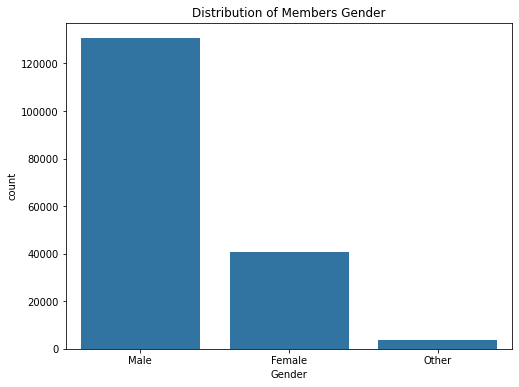

```python
order = df['member_gender'].value_counts().index
univariate_plot(x= 'member_gender', label= 'Gender', title= 'Distribution of Members Gender', order= order)
```

> We can observe a huge gap between Male and Female members (>85,000).

#### Plotting histogram of users types

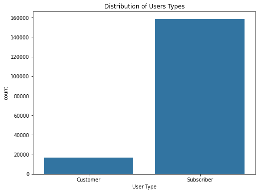

```python
univariate_plot(x= 'user_type', label= 'User Type', title= 'Distribution of Users Types')
```

> Subscribers tend to have much more rides than customers (>140,000). It makes sense once we think of it.

#### Plotting the distribution of Members age.

```python
df['member_age'].describe()
```

```
count    175147.000000
mean         34.193563
std          10.116689
min          18.000000
25%          27.000000
50%          32.000000
75%          39.000000
max         141.000000
Name: member_age, dtype: float64
```

> Maximum age (141 years) is, for sure, an outlier. So we will take the value where 99.5% of points lied before it as the maximum age.

```python
max_age = np.percentile(df['member_age'], 99.5)
```

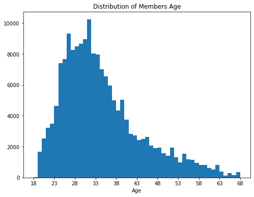

```python
plt.figure(figsize= (8, 6))
bins = np.arange(df['member_age'].min(), max_age+1)
ticks = np.arange(df['member_age'].min(), max_age+5, 5)
plt.hist(data= df, x= 'member_age', bins= bins)
plt.title('Distribution of Members Age')
plt.xlabel('Age')
plt.xticks(ticks, ['{}'.format(int(x)) for x in ticks])
plt.show()
```

> The distribution is slightly right-skewed. This is reasonable as youth and young people ride more than the old ones.

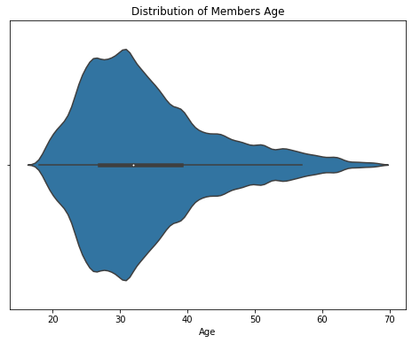

```python
df_age_80 = df[df['member_age'] <= max_age]

plt.figure(figsize= (8, 6))
sns.violinplot(data= df_age_80, x= 'member_age')
plt.title('Distribution of Members Age')
plt.xlabel('Age')
plt.show()
```

> Most ride members are aged around 30~35 years old. The number begins to decay hardly after 40 years old.

#### Distribution of rides in each week day

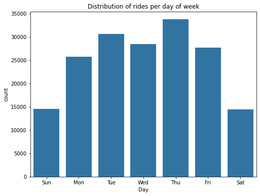

```python
days_order = ['Sun', 'Mon', 'Tue', 'Wed', 'Thu', 'Fri', 'Sat']
days_ordered = pd.Categorical(df['start_time'].dt.strftime('%a'), categories=days_order, ordered=True)

plt.figure(figsize= (8, 6))
sns.countplot(x= days_ordered, color= sns.color_palette()[0])
plt.title('Distribution of rides per day of week')
plt.xlabel('Day')
plt.show()
```

> The day of week with most rides is Thursday. While the ones with the lowest are Sunday and Saturday.

#### Distribution of rides per hour

```python
hours = [str(x).zfill(2) for x in range(24)]
```

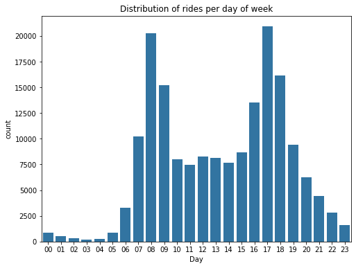

```python
hours_cat = pd.Categorical(df['start_time'].dt.strftime('%H'), ordered= True, categories= hours)

plt.figure(figsize= (8, 6))
sns.countplot(x= hours_cat, color= sns.color_palette()[0])
plt.title('Distribution of rides per day of week')
plt.xlabel('Day')
plt.show()
```

> We can observe that most of the rides start at **8 A.M.** and **5 P.M.**

```python
max_duration = np.percentile(df['duration_sec'], 99.5)

max_duration
```

```
5042.619999999937
```

**Note:** 99.5% of rides' durations lie below 5042 seconds. We can neglect the values beyond that.

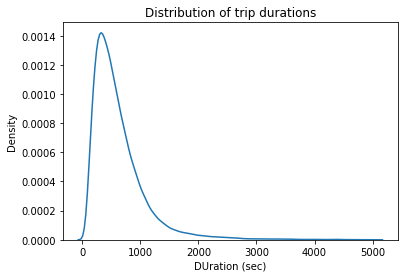

```python
sns.kdeplot(data= df[df['duration_sec'] <= max_duration], x= 'duration_sec')
plt.title('Distribution of trip durations')
plt.xlabel('DUration (sec)')
plt.show()
```

#### Adding a column for duration in minutes (to ease the investigation)

```python
df['duration_min'] = df['duration_sec'] // 60
```

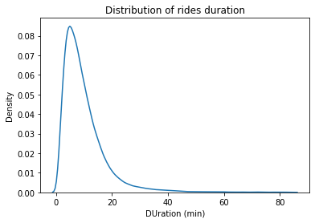

```python
sns.kdeplot(data= df[df['duration_min'] <= np.percentile(df['duration_min'], 99.5)], x= 'duration_min')
plt.title('Distribution of rides duration')
plt.xlabel('DUration (min)')
plt.show()
```

### Discuss the distribution(s) of your variable(s) of interest. Were there any unusual points? Did you need to perform any transformations?

> While investigating, I found the duration column has some outliers that affect the study of the column. I had to cut off the last 0.5% of the values and neglect them. I thought to add a new column for the duration in minutes as it will ease the study due to the vast range in durations in seconds.

### Of the features you investigated, were there any unusual distributions? Did you perform any operations on the data to tidy, adjust, or change the form of the data? If so, why did you do this?

> I added a column for member age by subtracting the birth year from current year. i.e. $year_{current} - year_{birth}$.  
> I also changed the dtype of 'start_time' and 'end_time' columns to datetime. That helped me to extract the ride's starting hour or day of week.

## Bivariate Exploration

```python
def bivariate_box_plot(x, y, title, xlabel, ylabel, color= 1):
    '''
    Plots boxplot between two variables.

    Args
    ----
    x: First variable. Located on x-axis.
    y: Second variable. Located on y-axis.
    title: The title of the plot.
    xlabel: The label of the x-axis.
    ylabel: The label of the y-axis.
    color: Index of a Seaborn's color-palette color.

    Return
    ------
    None
    '''
    plt.figure(figsize= (8, 6))

    sns.boxplot(data= df, x= x, y= y, color= sns.color_palette()[color])
    plt.title(title)
    plt.ylim(0, 40)
    plt.xlabel(xlabel)
    plt.ylabel(ylabel)

    plt.show()
```

### Checking correlation between trip duration and member's age

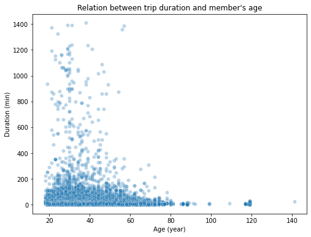

```python
plt.figure(figsize= (8, 6))
sns.scatterplot(data= df, x= 'member_age', y= 'duration_min', alpha= 0.3)
plt.title("Relation between trip duration and member's age")
plt.xlabel('Age (year)')
plt.ylabel('Duration (min)')
plt.show()
```

Durations are mostly below 400 minutes and age below 80 years.

Let's focus the plot on these ranges.

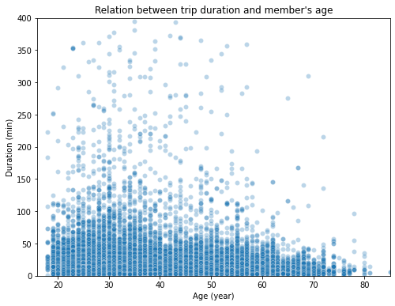

```python
plt.figure(figsize= (8, 6))

sns.scatterplot(data= df, x= 'member_age', y= 'duration_min', alpha= 0.3)
plt.xlim(df['member_age'].min() - 2, 85)
plt.ylim(0, 400)
plt.title("Relation between trip duration and member's age")
plt.xlabel('Age (year)')
plt.ylabel('Duration (min)')

plt.show()
```

### Trip duration vs Member Gender

```python
gender = pd.Categorical(df['member_gender'], ordered= True, categories = ['Male', 'Female', 'Other'])
```

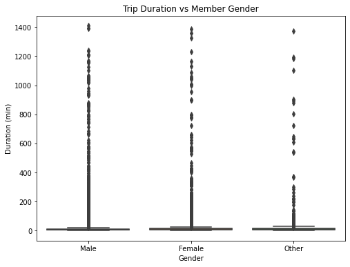

```python
plt.figure(figsize= (8, 6))

sns.boxplot(data= df, x= gender, y= 'duration_min')
plt.title("Trip Duration vs Member Gender")
plt.xlabel('Gender')
plt.ylabel('Duration (min)')

plt.show()
```

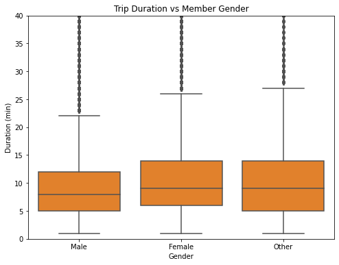

```python
bivariate_box_plot(x= gender, y= 'duration_min', title= "Trip Duration vs Member Gender",
                   xlabel= 'Gender', ylabel= 'Duration (min)', color= 1)
```

```python
df['member_gender'].value_counts().to_frame()
```

|  | member_gender |
| --- | --- |
| Male | 130651 |
| Female | 40844 |
| Other | 3652 |

Although the number of male riders are much more than female or others, we can see that higher number of females and others have longer rides durations than male riders.

### Trip Duration vs User Type

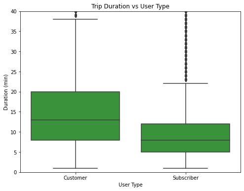

```python
bivariate_box_plot(x= 'user_type', y= 'duration_min', title= "Trip Duration vs User Type",
                   xlabel= 'User Type', ylabel= 'Duration (min)', color= 2)
```

We can observe that customers are more likely to have longer trips compared to subscribers.

### Member Gender vs User Type

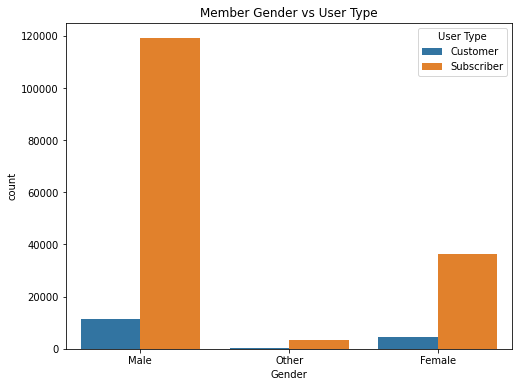

```python
plt.figure(figsize= (8, 6))

sns.countplot(data= df, x= 'member_gender', hue= 'user_type')
plt.title("Member Gender vs User Type")
plt.xlabel('Gender')
plt.legend(title= 'User Type')

plt.show()
```

### Talk about some of the relationships you observed in this part of the investigation. How did the feature(s) of interest vary with other features in the dataset?

> Trip duration depends on the member's age. Members aged between **30** and **40** years old have higher percentage of taking longer rides compared to other age ranges. While getting older, members are getting to take shorter rides. I can't tell that wasn't expected. As people age up, they can't do the same effort as before.

### Did you observe any interesting relationships between the other features (not the main feature(s) of interest)?

> I thought that males in gender features will have the higher trip durations, but I found it is not the case. And for the user type feature, I thought that subscribers will have longer trips than the customers but it was also the opposite.

## Multivariate Exploration

```python
def multivariate_plot(col, x, y, title, xlabel, ylabel):
    '''
    Plots scatter plot between two variables for each value of a third variable.

    Args
    ----
    col: The variable which we want to plot a scatter plot for every unique value of it.
    x: First variable. Located on x-axis.
    y: Second variable. Located on y-axis.
    title: The title of the plot.
    xlabel: The label of the x-axis.
    ylabel: The label of the y-axis.

    Return
    ------
    None
    '''
    col_wrap = len(df[col].value_counts())
    grid = sns.FacetGrid(data = df, col = col, col_wrap = col_wrap, size = 6,
                        xlim = [df[x].min() - 2, 85], ylim = [0, 400])

    grid.map(sns.scatterplot, x, y, alpha=0.3)
    grid.fig.suptitle(title)
    grid.fig.subplots_adjust(top=0.9)
    grid.set_xlabels(xlabel)
    grid.set_ylabels(ylabel)

    plt.show()
```

### Trip Duration vs Member's age, for different member's gender

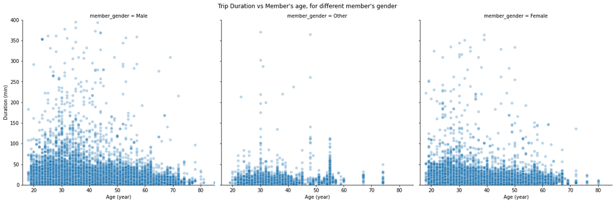

```python
multivariate_plot(col= 'member_gender', x= 'member_age', y= 'duration_min',
                  title= "Trip Duration vs Member's age, for different member's gender",
                  xlabel= 'Age (year)', ylabel= 'Duration (min)')
```

> Surprisingly, 'Other' gender has another peak of trip durations for riders aged between 55~60 years old.

### Trip Duration vs Member's age, for different user type

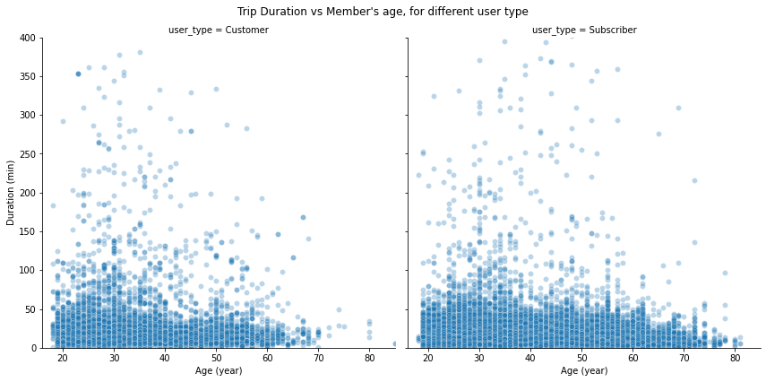

```python
multivariate_plot(col= 'user_type', x= 'member_age', y= 'duration_min',
                  title= "Trip Duration vs Member's age, for different user type",
                  xlabel= 'Age (year)', ylabel= 'Duration (min)')
```

> Both 'Customer' and 'Subscriber' types almost have the same trend.

### Talk about some of the relationships you observed in this part of the investigation. Were there features that strengthened each other in terms of looking at your feature(s) of interest?

> 'Other' gender has one more peak between the age of 55~60 years old for higher duration time.  
> For different user types both are showing almost the same trend for age and trip duration. But there are more 'Subscribers' aged above **65** years old than 'Customers'.

### Were there any interesting or surprising interactions between features?

> There is a peak between 55~60 years old in 'Other' gender.